# ¿Se asocia una oferta alimentaria más diversa con más energía, grasa y calidad? Análisis diagnóstico de panel en Sudamérica (FAO, 2010-2023) y pronóstico breve de la energía

Juan Salazar y Luz Ríos

19 de octubre de 2026

```r
ruta <- file.path("data", "processed")  # relativo a la raíz del repo (ver scripts/render.R)
panel <- read_csv(file.path(ruta, "panel_pais_anio_definitivo.csv"), show_col_types = FALSE) |>
  clean_names() |>
  arrange(pais, ano)
kpis  <- read_csv(file.path(ruta, "paises_definitivo_kpis.csv"), show_col_types = FALSE) |> clean_names()

anios   <- sort(unique(panel$ano))
paises  <- sort(unique(panel$pais))
G       <- length(paises)          # número de países = número de grupos (clústeres)
T_      <- length(anios)           # años por país
equilibrado <- nrow(panel) == G * T_ && all(count(panel, pais)$n == T_)

# Diversidad estandarizada (misma definición que en el informe descriptivo v3):
# food_diversity_index = Shannon (ln) sobre los 13 grupos; se estandariza con la DE de las 140 observaciones.
sd_div_pool   <- sd(panel$food_diversity_index)
sd_div_within <- sd(panel$food_diversity_index - ave(panel$food_diversity_index, panel$pais))
sd_div_between <- sd(tapply(panel$food_diversity_index, panel$pais, mean))
panel <- panel |>
  mutate(div_z = (food_diversity_index - mean(food_diversity_index)) / sd_div_pool,
         t_c = ano - min(ano))

resultados <- c("kcal_dia_total", "grasa_g_dia_total", "indice_calidad_oferta")
et_res     <- c("Energía", "Grasa", "Índice de calidad")
unid       <- c("kcal/día", "g/día", "puntos")
names(et_res) <- names(unid) <- resultados
media_y <- map_dbl(resultados, ~ mean(panel[[.x]])); names(media_y) <- resultados

pp <- pdata.frame(as.data.frame(panel), index = c("pais", "ano"))
```

# 1 Introducción y especificación

## 1.1 Pregunta e hipótesis

El informe descriptivo previo (v3) describió la oferta alimentaria de 10 países de Sudamérica entre 2010 y 2023 y recomendó que la siguiente etapa fuera **diagnóstica**: pasar de describir a contrastar relaciones con un modelo de panel y una inferencia adecuada para pocos grupos. Esta es esa etapa. La pregunta es:

> **Dentro de cada país y a lo largo de 2010-2023, ¿los años en que la oferta alimentaria es más diversa son también años con más energía, más grasa y mejor calidad de la oferta?**

Hipótesis (todas **asociacionales**; ninguna pretende establecer causalidad):

- **H1.** Mayor diversidad se asocia con más energía disponible (kcal por persona y día).
- **H2.** Mayor diversidad se asocia con más grasa disponible (g por persona y día).
- **H3.** Mayor diversidad se asocia con un mayor índice de calidad de la oferta (`indice_calidad_oferta`, parcial: considera solo frutas y hortalizas y energía de grasa).

La **proteína no está en el panel** (solo existe en los indicadores por país de la ventana 2019-2023), así que no puede estudiarse dentro de cada país a lo largo del tiempo; el informe v3 la trató solo entre países y aquí queda fuera del modelo.

Estos resultados describen **asociaciones**, no efectos causales: con datos observacionales agregados no se puede descartar que otras variables (ingreso, precios, clima, políticas) muevan a la vez la diversidad y los nutrientes, ni que la relación sea en parte mecánica (el índice de diversidad se calcula con la misma oferta que determina la energía y la grasa).

## 1.2 Por qué la variación *dentro* de cada país

En el panel (140 filas = 10 países x 14 años, equilibrado), las diferencias **entre** países (clima, cultura alimentaria, tamaño y estructura productiva) son grandes y permanentes y mezclan muchas causas. El informe v3 ya mostró que, entre países, ninguna asociación de la diversidad resiste la corrección por pruebas múltiples. Lo informativo es comparar cada país **consigo mismo** en distintos años: los *efectos fijos de país* eliminan todo lo que no cambia en el tiempo dentro de cada país, aunque no se haya medido. La contrapartida es que la variación que queda es pequeña: la desviación estándar de la diversidad es 0.056 en el panel completo, 0.056 entre promedios de país y solo 0.019 dentro de los países.

## 1.3 Especificación

Para el país $i$ y el año $t$, con resultado $y_{it}$ (energía, grasa o calidad):

$$y_{it} = \alpha_i + \beta \,
\text{Div}_{it} + \gamma \, t + \varepsilon_{it}$$

donde $\text{Div}_{it}$ es el índice de Shannon estandarizado, $\alpha_i$ es el efecto fijo del país y $t$ es una tendencia lineal común. La variante *bidireccional* (two-way) reemplaza $\gamma t$ por efectos de año $\lambda_t$: $y_{it} = \alpha_i + \lambda_t + \beta \,\text{Div}_{it} + \varepsilon_{it}$.

- **Diversidad estandarizada.** $\text{Div}_{it}$ = (índice - media) / DE, con la **DE del panel completo** (0.056, no la intra-país). Por eso $\beta$ se lee como “cambio en el resultado por cada **+1 DE de diversidad del panel**”, unidad comparable con el informe v3. Como la DE intra-país es 0.34 veces la del panel, un movimiento de +1 DE del panel es más grande que lo que típicamente cambia un país a lo largo del tiempo; el coeficiente por unidad de DE intra-país se obtiene multiplicando por ese factor.
- **Controles.** Se incluyen **efectos fijos de país** y una **tendencia común** (o efectos de año en la variante bidireccional): la energía, la diversidad y la dependencia de importaciones suben con el tiempo en la región (informe v3), y sin control temporal la regresión captaría esa tendencia compartida. **No** se añaden controles de comercio exterior en el modelo principal, porque la dependencia de importaciones o la autosuficiencia pueden ser *mediadores* (la apertura comercial puede ampliar la variedad, y esa variedad influir en los nutrientes): controlar por ellos eliminaría parte del canal que se quiere medir (*mala práctica de “control malo”*). Se prueba como análisis de sensibilidad en la sección de robustez, con esa advertencia.
- **Variables excluidas.** No se usa la columna `cluster` del panel (informe v3: no tiene una definición consistente).
- **Efecto como % de la media.** Además del coeficiente en unidades, se reporta el efecto dividido por la media del resultado en el panel (Energía 2 915.5 kcal/día; Grasa 95.0 g/día; Índice de calidad 92.9 puntos), para comparar la magnitud entre resultados.

# 2 Modelos principales

```r
ajustar <- function(y, datos = pp) {
  f1 <- as.formula(paste(y, "~ div_z + t_c"))
  f2_ <- as.formula(paste(y, "~ div_z"))
  list(pooled = plm(f1, datos, model = "pooling"),
       fe     = plm(f1, datos, model = "within"),
       re     = plm(f1, datos, model = "random"),
       fe2    = plm(f2_, datos, model = "within", effect = "twoways"))
}
mods <- map(set_names(resultados), ajustar)

vc_cl <- function(m) vcovHC(m, method = "arellano", type = "HC1", cluster = "group")
lag_dk <- 2
vc_dk <- function(m) vcovSCC(m, type = "HC1", maxlag = lag_dk)
gl_t  <- G - 1   # grados de libertad t con G clústeres (criterio conservador)

et_mod <- c(pooled = "MCO agrupado (pooled)", fe = "Efectos fijos de país + tendencia",
            re = "Efectos aleatorios + tendencia", fe2 = "Efectos fijos de país y de año")

tab_mod <- map_dfr(resultados, function(y) {
  imap_dfr(mods[[y]], function(m, nm) {
    vc <- vc_cl(m); b <- unname(coef(m)["div_z"]); se <- sqrt(vc["div_z", "div_z"])
    tibble(resultado = et_res[y], modelo = et_mod[nm], coef = b, pct_media = 100 * b / media_y[y],
           ee_agrupado = se, p_agrupado = 2 * pt(-abs(b / se), gl_t))
  })
})
tab_mod |> mutate(p_agrupado = fpt(p_agrupado)) |>
  kable(digits = c(0, 0, 2, 2, 2, 0), col.names = c("Resultado", "Modelo", "Coef. por +1 DE", "% de la media", "EE (agrupado por país)", "p (t con G-1 gl)"),
        caption = "Asociación de +1 DE de diversidad con cada resultado, según el modelo (errores agrupados por país)")
```

Asociación de +1 DE de diversidad con cada resultado, según el modelo (errores agrupados por país)

| Resultado | Modelo | Coef. por +1 DE | % de la media | EE (agrupado por país) | p (t con G-1 gl) |
| --- | --- | --- | --- | --- | --- |
| Energía | MCO agrupado (pooled) | 174.75 | 5.99 | 44.62 | 0.004 |
| Energía | Efectos fijos de país + tendencia | 74.24 | 2.55 | 17.38 | 0.002 |
| Energía | Efectos aleatorios + tendencia | 83.09 | 2.85 | 16.20 | < 0.001 |
| Energía | Efectos fijos de país y de año | 81.90 | 2.81 | 23.89 | 0.008 |
| Grasa | MCO agrupado (pooled) | 7.33 | 7.72 | 5.14 | 0.187 |
| Grasa | Efectos fijos de país + tendencia | 11.37 | 11.97 | 2.51 | 0.001 |
| Grasa | Efectos aleatorios + tendencia | 11.19 | 11.78 | 2.49 | 0.001 |
| Grasa | Efectos fijos de país y de año | 12.30 | 12.95 | 2.76 | 0.002 |
| Índice de calidad | MCO agrupado (pooled) | 2.23 | 2.40 | 3.21 | 0.505 |
| Índice de calidad | Efectos fijos de país + tendencia | -2.60 | -2.80 | 1.89 | 0.203 |
| Índice de calidad | Efectos aleatorios + tendencia | -1.70 | -1.83 | 1.93 | 0.401 |
| Índice de calidad | Efectos fijos de país y de año | -2.72 | -2.93 | 2.00 | 0.207 |

Lectura: el modelo **agrupado** y el de **efectos aleatorios** mezclan comparaciones entre países y dentro de cada país; el de **efectos fijos** usa solo la variación dentro de cada país; el **bidireccional** además elimina cualquier shock común a todos los países en un mismo año (por ejemplo, un cambio metodológico de la FAO o un shock regional de precios).

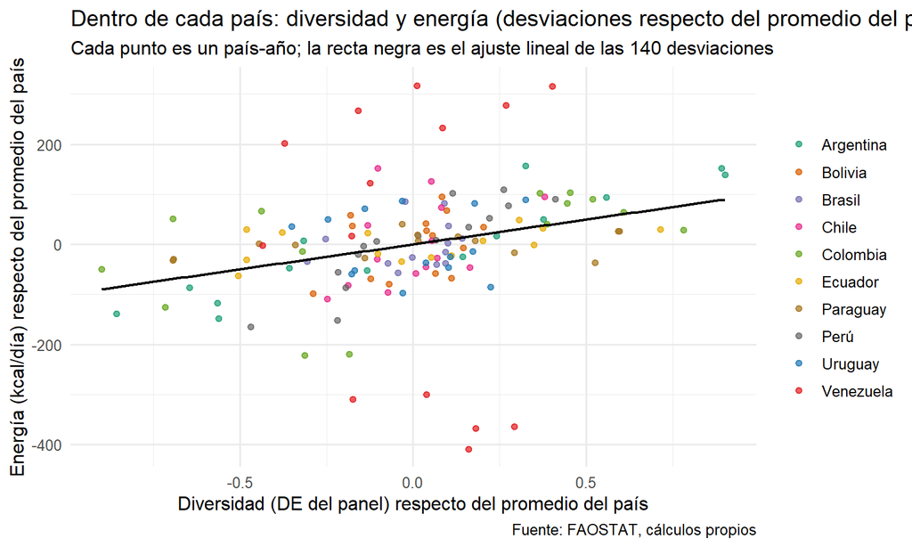

```r
panel |>
  mutate(div_dm = div_z - ave(div_z, pais),
         kcal_dm = kcal_dia_total - ave(kcal_dia_total, pais)) |>
  ggplot(aes(div_dm, kcal_dm, color = pais)) +
  geom_point(alpha = 0.7) +
  geom_smooth(aes(group = 1), method = "lm", se = FALSE, color = "black", linewidth = 0.8) +
  scale_color_manual(values = paleta_paises) +
  labs(title = "Dentro de cada país: diversidad y energía (desviaciones respecto del promedio del país)",
       subtitle = "Cada punto es un país-año; la recta negra es el ajuste lineal de las 140 desviaciones",
       x = "Diversidad (DE del panel) respecto del promedio del país",
       y = "Energía (kcal/día) respecto del promedio del país", color = NULL, caption = fuente)
```

## 2.1 Efectos fijos o aleatorios: prueba de Hausman

La prueba de Hausman contrasta si el estimador de efectos aleatorios (más eficiente) coincide con el de efectos fijos (más robusto). Si **se rechaza**, los efectos de país están correlacionados con la diversidad y los efectos aleatorios serían inconsistentes: se prefieren los fijos. Se reportan la versión clásica y una versión robusta (variante de Mundlak: regresión con el promedio por país de la diversidad y errores agrupados), porque la clásica supone errores homocedásticos e independientes.

```r
haus <- map_dfr(resultados, function(y) {
  h1 <- tryCatch(phtest(mods[[y]]$fe, mods[[y]]$re), error = function(e) NULL)
  # Versión robusta (Mundlak): se añade el promedio por país de la diversidad; H0: su coeficiente es 0
  # (equivalente al contraste de Hausman para el regresor que varía en el tiempo), con errores agrupados por país
  dd <- panel |> mutate(div_bar = ave(div_z, pais))
  h2 <- tryCatch({
    mm <- lm(as.formula(paste(y, "~ div_z + t_c + div_bar")), data = dd)
    ct <- coeftest(mm, vcov. = vcovCL(mm, cluster = dd$pais, type = "HC1"))
    2 * pt(-abs(ct["div_bar", "Estimate"] / ct["div_bar", "Std. Error"]), gl_t)
  }, error = function(e) NA_real_)
  tibble(resultado = et_res[y],
         chi2 = if (!is.null(h1)) unname(h1$statistic) else NA_real_,
         gl = if (!is.null(h1)) unname(h1$parameter) else NA_real_,
         p_clasico = if (!is.null(h1)) h1$p.value else NA_real_,
         p_robusto = h2)
})
haus <- haus |> mutate(decision = case_when(is.na(p_clasico) ~ "No disponible",
                                           p_clasico < 0.05 ~ "Se rechaza RE: usar efectos fijos",
                                           TRUE ~ "No se rechaza RE"))
haus |> mutate(across(starts_with("p_"), fpt)) |>
  kable(digits = 2, col.names = c("Resultado", "Chi-cuadrado", "gl", "p (clásico)", "p (robusto)", "Decisión (clásico, 5 %)"),
        caption = "Prueba de Hausman: efectos fijos frente a aleatorios")
```

Prueba de Hausman: efectos fijos frente a aleatorios

| Resultado | Chi-cuadrado | gl | p (clásico) | p (robusto) | Decisión (clásico, 5 %) |
| --- | --- | --- | --- | --- | --- |
| Energía | 1.23 | 2 | 0.541 | 0.066 | No se rechaza RE |
| Grasa | 0.30 | 2 | 0.862 | 0.507 | No se rechaza RE |
| Índice de calidad | 3.72 | 2 | 0.156 | 0.192 | No se rechaza RE |

Resultado de la prueba: **Energía**: chi-cuadrado = 1.23 (2 gl), p = 0.541 (versión robusta: p = 0.066); no hay evidencia suficiente contra los efectos aleatorios. **Grasa**: chi-cuadrado = 0.30 (2 gl), p = 0.862 (versión robusta: p = 0.507); no hay evidencia suficiente contra los efectos aleatorios. **Índice de calidad**: chi-cuadrado = 3.72 (2 gl), p = 0.156 (versión robusta: p = 0.192); no hay evidencia suficiente contra los efectos aleatorios. La versión robusta se acerca al rechazo en energía (p < 0.10), lo que sugiere cierta correlación entre los efectos de país y la diversidad que la prueba clásica no detecta. En ningún caso se rechaza la igualdad; aun así, con solo diez países la prueba tiene poca potencia, y se mantienen los efectos fijos como modelo principal por ser la comparación intra-país más prudente.

# 3 Inferencia con pocos grupos

Con solo 10 países, los errores estándar “de manual” y aun los agrupados por país pueden ser demasiado optimistas (la teoría de los errores agrupados exige muchos grupos). Por eso el coeficiente principal se evalúa con cinco enfoques:

1. **Clásico**: supone errores independientes y homocedásticos (se muestra solo como referencia).
2. **Agrupado por país** (Arellano, HC1): permite correlación arbitraria dentro de cada país a lo largo del tiempo; p con distribución $t$ de 9 grados de libertad ($G-1$).
3. **Driscoll-Kraay** (rezago 2): además admite correlación entre países en un mismo año, pero requiere muchos años; con $T$ = 14 es aproximado.
4. **Bootstrap salvaje por país con pesos de Webb** (*wild cluster bootstrap*, versión restringida: se impone la hipótesis nula y se remuestrea el residuo multiplicado por un peso aleatorio común a todo el país). Se implementó manualmente (1999 réplicas, semilla fija). Los pesos de Webb toman seis valores, lo que da una distribución mucho más rica que la de dos valores cuando hay pocos grupos. El IC se aproxima como coef. $\pm$ el cuantil 95 % de $|t^*|$ por el error estándar agrupado.
5. **Bootstrap salvaje con pesos de Rademacher (exacto)**: con $G$ = 10 países solo existen $2^{G}$ = 1024 combinaciones de signos (la mitad dan el mismo valor absoluto), por lo que no tiene sentido simular: se **enumeran todas**. Se muestra como verificación.

```r
webb <- c(-sqrt(1.5), -1, -sqrt(0.5), sqrt(0.5), 1, sqrt(1.5))
n_boot <- 1999

# Transformación within (equilibrado): desviaciones respecto de país (y de año si dos = TRUE)
D2 <- function(x, dos) {
  x <- as.matrix(x)
  r <- x - apply(x, 2, function(c) ave(c, panel$pais))
  if (dos) r <- r - apply(x, 2, function(c) ave(c, panel$ano)) + matrix(colMeans(x), nrow(x), ncol(x), byrow = TRUE)
  r
}

wcb <- function(y, dos, tipo = c("webb", "rademacher"), B = n_boot, semilla = 20240601) {
  tipo <- match.arg(tipo)
  X  <- if (dos) cbind(div_z = panel$div_z) else cbind(div_z = panel$div_z, t_c = panel$t_c)
  Xd <- D2(X, dos); yd <- D2(y, dos)[, 1]
  gi <- match(panel$pais, paises); N <- nrow(Xd); K <- ncol(Xd)
  XtXi <- solve(crossprod(Xd))
  est <- function(yy) {                      # coeficiente de div_z y EE agrupado (CR1)
    b <- XtXi %*% crossprod(Xd, yy); e <- as.vector(yy - Xd %*% b)
    S <- rowsum(Xd * e, gi)
    V <- XtXi %*% crossprod(S) %*% XtXi * G / (G - 1) * (N - 1) / (N - K)
    c(b[1], sqrt(V[1, 1]))
  }
  o <- est(yd); t0 <- o[1] / o[2]
  if (dos) fit_r <- rep(0, N) else {          # modelo restringido (sin diversidad)
    Xr <- Xd[, 2, drop = FALSE]; fit_r <- as.vector(Xr %*% solve(crossprod(Xr), crossprod(Xr, yd)))
  }
  u <- yd - fit_r
  W <- if (tipo == "rademacher") as.matrix(expand.grid(rep(list(c(-1, 1)), G)))
       else { set.seed(semilla); matrix(sample(webb, B * G, replace = TRUE), B, G) }
  ts_ <- apply(W, 1, function(w) { ys <- fit_r + D2(w[gi] * u, dos)[, 1]; r <- est(ys); r[1] / r[2] })
  p <- if (tipo == "rademacher") mean(abs(ts_) >= abs(t0) - 1e-12) else (1 + sum(abs(ts_) >= abs(t0))) / (length(ts_) + 1)
  q95 <- unname(quantile(abs(ts_), 0.95))
  list(b = o[1], se = o[2], t = t0, p = p, lo = o[1] - q95 * o[2], hi = o[1] + q95 * o[2], n_sim = length(ts_))
}

metodos <- c("Clásico (referencia)", "Agrupado por país (HC1)", "Driscoll-Kraay",
             "Bootstrap salvaje (Webb)", "Bootstrap salvaje (Rademacher, exacto)")

inferencia <- function(dos) {
  out <- map_dfr(resultados, function(y) {
    m <- if (dos) mods[[y]]$fe2 else mods[[y]]$fe
    b <- unname(coef(m)["div_z"])
    analit <- function(vc) { se <- sqrt(vc["div_z", "div_z"])
      tibble(coef = b, lo = b - qt(0.975, gl_t) * se, hi = b + qt(0.975, gl_t) * se, p = 2 * pt(-abs(b / se), gl_t)) }
    bw <- wcb(panel[[y]], dos, "webb"); br <- wcb(panel[[y]], dos, "rademacher")
    bind_rows(analit(vcov(m)), analit(vc_cl(m)), analit(vc_dk(m)),
              tibble(coef = bw$b, lo = bw$lo, hi = bw$hi, p = bw$p),
              tibble(coef = br$b, lo = br$lo, hi = br$hi, p = br$p)) |>
      mutate(resultado = y, metodo = metodos, .before = 1)
  })
  out |> group_by(metodo) |> mutate(p_holm = p.adjust(p, "holm")) |> ungroup() |>
    mutate(pct_media = 100 * coef / media_y[resultado], sig = p < 0.05, sig_holm = p_holm < 0.05)
}
inf_fe  <- inferencia(FALSE)
inf_fe2 <- inferencia(TRUE)
```

```r
tab_inf <- function(d, cap) {
  d |> mutate(resultado = et_res[resultado], p = fpt(p), p_holm = fpt(p_holm)) |>
    arrange(match(resultado, et_res), match(metodo, metodos)) |>
    select(resultado, metodo, coef, lo, hi, pct_media, p, p_holm) |>
    kable(digits = c(0, 0, 2, 2, 2, 2, 0, 0), caption = cap,
          col.names = c("Resultado", "Método", "Coef. por +1 DE", "IC 95 % inf.", "IC 95 % sup.", "% de la media", "p", "p (Holm, 3 resultados)"))
}
tab_inf(inf_fe, "Efectos fijos de país + tendencia: coeficiente, IC y valor p por método de inferencia (Holm aplicado dentro de cada método a los tres resultados)")
```

Efectos fijos de país + tendencia: coeficiente, IC y valor p por método de inferencia (Holm aplicado dentro de cada método a los tres resultados)

| Resultado | Método | Coef. por +1 DE | IC 95 % inf. | IC 95 % sup. | % de la media | p | p (Holm, 3 resultados) |
| --- | --- | --- | --- | --- | --- | --- | --- |
| Energía | Clásico (referencia) | 74.24 | 9.44 | 139.05 | 2.55 | 0.029 | 0.058 |
| Energía | Agrupado por país (HC1) | 74.24 | 34.92 | 113.57 | 2.55 | 0.002 | 0.004 |
| Energía | Driscoll-Kraay | 74.24 | 19.43 | 129.06 | 2.55 | 0.013 | 0.027 |
| Energía | Bootstrap salvaje (Webb) | 74.24 | 17.99 | 130.50 | 2.55 | 0.012 | 0.038 |
| Energía | Bootstrap salvaje (Rademacher, exacto) | 74.24 | 16.10 | 132.39 | 2.55 | 0.021 | 0.064 |
| Grasa | Clásico (referencia) | 11.37 | 7.81 | 14.93 | 11.97 | < 0.001 | < 0.001 |
| Grasa | Agrupado por país (HC1) | 11.37 | 5.68 | 17.06 | 11.97 | 0.001 | 0.004 |
| Grasa | Driscoll-Kraay | 11.37 | 6.41 | 16.33 | 11.97 | < 0.001 | 0.002 |
| Grasa | Bootstrap salvaje (Webb) | 11.37 | 2.07 | 20.67 | 11.97 | 0.016 | 0.038 |
| Grasa | Bootstrap salvaje (Rademacher, exacto) | 11.37 | 0.78 | 21.96 | 11.97 | 0.033 | 0.066 |
| Índice de calidad | Clásico (referencia) | -2.60 | -5.30 | 0.10 | -2.80 | 0.058 | 0.058 |
| Índice de calidad | Agrupado por país (HC1) | -2.60 | -6.88 | 1.68 | -2.80 | 0.203 | 0.203 |
| Índice de calidad | Driscoll-Kraay | -2.60 | -6.53 | 1.33 | -2.80 | 0.169 | 0.169 |
| Índice de calidad | Bootstrap salvaje (Webb) | -2.60 | -7.81 | 2.62 | -2.80 | 0.256 | 0.256 |
| Índice de calidad | Bootstrap salvaje (Rademacher, exacto) | -2.60 | -7.97 | 2.77 | -2.80 | 0.250 | 0.250 |

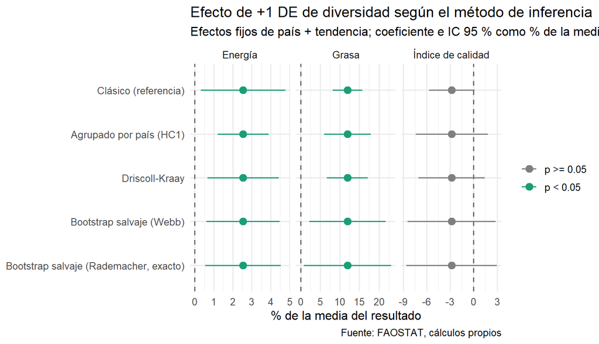

```r
inf_fe |>
  mutate(res = factor(et_res[resultado], levels = et_res), metodo = factor(metodo, levels = rev(metodos))) |>
  ggplot(aes(100 * coef / media_y[resultado], metodo, color = sig)) +
  geom_vline(xintercept = 0, linetype = "dashed", color = "grey40") +
  geom_pointrange(aes(xmin = 100 * lo / media_y[resultado], xmax = 100 * hi / media_y[resultado])) +
  scale_color_manual(values = c(`TRUE` = "#1B9E77", `FALSE` = "grey50"), labels = c(`TRUE` = "p < 0.05", `FALSE` = "p >= 0.05"), name = NULL) +
  facet_wrap(~res, scales = "free_x") +
  labs(title = "Efecto de +1 DE de diversidad según el método de inferencia",
       subtitle = "Efectos fijos de país + tendencia; coeficiente e IC 95 % como % de la media del resultado",
       x = "% de la media del resultado", y = NULL, caption = fuente)
```

**Resultados con efectos fijos de país y tendencia.** **Energía**: +74.2 kcal/día por +1 DE (+2.55 % de la media); IC 95 % bootstrap [17.99; 130.50]; p agrupado = 0.002, p Driscoll-Kraay = 0.013, p bootstrap Webb = 0.012, p Holm = 0.038. **Grasa**: +11.4 g/día por +1 DE (+11.97 % de la media); IC 95 % bootstrap [2.07; 20.67]; p agrupado = 0.001, p Driscoll-Kraay < 0.001, p bootstrap Webb = 0.016, p Holm = 0.038. **Índice de calidad**: -2.60 puntos por +1 DE (-2.80 % de la media); IC 95 % bootstrap [-7.81; 2.62]; p agrupado = 0.203, p Driscoll-Kraay = 0.169, p bootstrap Webb = 0.256, p Holm = 0.256.

- Con el bootstrap salvaje (Webb), 2 de 3 asociaciones son significativas al 5 % y 2 lo siguen siendo tras Holm; con errores agrupados, 2; con Driscoll-Kraay, 2.
- El método de inferencia no altera ninguna conclusión de significancia al 5 % entre el agrupado y el bootstrap.
- El IC del bootstrap para la energía es 1.43 veces el ancho del IC agrupado (más amplio, como se espera de un método que no supone muchos grupos). Los pesos de Rademacher (enumeración exacta de 1024 combinaciones) y los de Webb difieren en p como máximo en 0.017.

La variante con **efectos de año** (bidireccional), que además absorbe cualquier shock común a todos los países, da:

```r
tab_inf(inf_fe2, "Efectos fijos de país y de año: coeficiente, IC y valor p por método de inferencia")
```

Efectos fijos de país y de año: coeficiente, IC y valor p por método de inferencia

| Resultado | Método | Coef. por +1 DE | IC 95 % inf. | IC 95 % sup. | % de la media | p | p (Holm, 3 resultados) |
| --- | --- | --- | --- | --- | --- | --- | --- |
| Energía | Clásico (referencia) | 81.90 | 14.07 | 149.73 | 2.81 | 0.023 | 0.046 |
| Energía | Agrupado por país (HC1) | 81.90 | 27.87 | 135.94 | 2.81 | 0.008 | 0.015 |
| Energía | Driscoll-Kraay | 81.90 | 27.69 | 136.12 | 2.81 | 0.008 | 0.015 |
| Energía | Bootstrap salvaje (Webb) | 81.90 | 7.52 | 156.29 | 2.81 | 0.036 | 0.073 |
| Energía | Bootstrap salvaje (Rademacher, exacto) | 81.90 | 2.93 | 160.88 | 2.81 | 0.041 | 0.111 |
| Grasa | Clásico (referencia) | 12.30 | 8.70 | 15.91 | 12.95 | < 0.001 | < 0.001 |
| Grasa | Agrupado por país (HC1) | 12.30 | 6.05 | 18.56 | 12.95 | 0.002 | 0.005 |
| Grasa | Driscoll-Kraay | 12.30 | 7.68 | 16.92 | 12.95 | < 0.001 | < 0.001 |
| Grasa | Bootstrap salvaje (Webb) | 12.30 | 1.64 | 22.97 | 12.95 | 0.018 | 0.054 |
| Grasa | Bootstrap salvaje (Rademacher, exacto) | 12.30 | 0.68 | 23.92 | 12.95 | 0.037 | 0.111 |
| Índice de calidad | Clásico (referencia) | -2.72 | -5.60 | 0.16 | -2.93 | 0.061 | 0.061 |
| Índice de calidad | Agrupado por país (HC1) | -2.72 | -7.25 | 1.80 | -2.93 | 0.207 | 0.207 |
| Índice de calidad | Driscoll-Kraay | -2.72 | -6.54 | 1.10 | -2.93 | 0.142 | 0.142 |
| Índice de calidad | Bootstrap salvaje (Webb) | -2.72 | -8.01 | 2.56 | -2.93 | 0.262 | 0.262 |
| Índice de calidad | Bootstrap salvaje (Rademacher, exacto) | -2.72 | -8.00 | 2.56 | -2.93 | 0.262 | 0.262 |

Con efectos de año, 2 de 3 asociaciones son significativas con el bootstrap Webb y 0 tras Holm.

# 4 Diagnósticos de los errores

Los supuestos de los errores determinan qué errores estándar son creíbles. Se contrastan en el modelo de efectos fijos: **autocorrelación serial** (Breusch-Godfrey de panel y Wooldridge), **dependencia entre países** en el mismo año (Pesaran CD, con y sin efectos de año) y **heterocedasticidad** (Breusch-Pagan sobre el modelo con dummies de país).

```r
diag_tab <- map_dfr(resultados, function(y) {
  m <- mods[[y]]$fe; m2 <- mods[[y]]$fe2
  bg  <- tryCatch(pbgtest(m, order = 1), error = function(e) NULL)
  wa  <- tryCatch(pwartest(m), error = function(e) NULL)
  cd  <- tryCatch(pcdtest(m, test = "cd"), error = function(e) NULL)
  cd2 <- tryCatch(pcdtest(m2, test = "cd"), error = function(e) NULL)
  bp  <- tryCatch(bptest(lm(as.formula(paste(y, "~ div_z + t_c + factor(pais)")), data = panel)), error = function(e) NULL)
  g <- function(x, w = "p.value") if (is.null(x)) NA_real_ else unname(x[[w]])
  tibble(resultado = et_res[y], p_bg = g(bg), p_wooldridge = g(wa), cd_estad = g(cd, "statistic"), p_cd = g(cd),
         p_cd_anio = g(cd2), p_bp = g(bp))
})
diag_tab |> mutate(across(starts_with("p_"), fpt)) |>
  kable(digits = 2, col.names = c("Resultado", "p Breusch-Godfrey (orden 1)", "p Wooldridge", "Estad. CD (EF país)", "p CD (EF país)", "p CD (EF país y año)", "p Breusch-Pagan"),
        caption = "Diagnósticos de los residuos (valores p; H0: sin autocorrelación / sin dependencia / homocedasticidad)")
```

Diagnósticos de los residuos (valores p; H0: sin autocorrelación / sin dependencia / homocedasticidad)

| Resultado | p Breusch-Godfrey (orden 1) | p Wooldridge | Estad. CD (EF país) | p CD (EF país) | p CD (EF país y año) | p Breusch-Pagan |
| --- | --- | --- | --- | --- | --- | --- |
| Energía | < 0.001 | < 0.001 | 0.11 | 0.913 | 0.147 | < 0.001 |
| Grasa | < 0.001 | < 0.001 | 0.79 | 0.429 | 0.038 | < 0.001 |
| Índice de calidad | < 0.001 | < 0.001 | -0.81 | 0.417 | 0.226 | < 0.001 |

**Implicaciones.** 3 de 3 resultados muestran autocorrelación serial al 5 % en al menos una de las dos pruebas: los residuos de un mismo país se parecen de un año al siguiente, de modo que los errores clásicos subestiman la incertidumbre y se justifica agrupar por país. La dependencia entre países en el mismo año es significativa en 0 de 3 resultados con efectos fijos de país; con efectos de año lo es en 1 de 3, así que no se descarta algún shock común residual. La heterocedasticidad es significativa en 3 de 3 resultados. **Qué errores creer:** con pocos grupos y estos problemas, el criterio más confiable es el **bootstrap salvaje por país** (no supone muchos grupos y respeta la correlación dentro de país), seguido del agrupado con $t_{G-1}$; Driscoll-Kraay se interpreta con cautela porque está pensado para series largas, y el error clásico no debe usarse para decidir.

# 5 Robustez

Se repite la estimación principal (efectos fijos de país con tendencia) cambiando una decisión cada vez. En todas las variantes los valores p usan errores agrupados por país con distribución $t$ de (grupos - 1) grados de libertad: son menos exigentes que el bootstrap salvaje, de modo que sirven para comparar variantes entre sí, no para reemplazar la inferencia principal.

```r
a_pdf <- function(d) pdata.frame(as.data.frame(d), index = c("pais", "ano"))
est_rob <- function(etq, y, d, xvar = "div_z", extra = NULL, model = "within", effect = "individual", trend = TRUE) {
  rhs <- c(xvar, if (trend) "t_c", extra)
  m <- plm(as.formula(paste(y, "~", paste(rhs, collapse = " + "))), a_pdf(d), model = model, effect = effect)
  vc <- vcovHC(m, method = "arellano", type = "HC1", cluster = "group")
  Gm <- pdim(m)$nT$n; gl <- Gm - 1
  b <- unname(coef(m)[xvar]); se <- sqrt(vc[xvar, xvar])
  tibble(verificacion = etq, resultado = y, coef = b, se = se, p = 2 * pt(-abs(b / se), gl),
         lo = b - qt(0.975, gl) * se, hi = b + qt(0.975, gl) * se, n = nobs(m), grupos = Gm)
}

# Años de crisis de Venezuela, definidos desde los datos: kcal por debajo del 85 % de su promedio
# de los primeros cinco años (período previo estable de la serie)
ven <- filter(panel, pais == "Venezuela")
umbral_crisis <- 0.85
base_ven <- mean(ven$kcal_dia_total[ven$ano < min(anios) + 5])
anios_crisis <- ven$ano[ven$kcal_dia_total < umbral_crisis * base_ven]
panel_sc <- filter(panel, !(pais == "Venezuela" & ano %in% anios_crisis))
panel_lag <- panel |> group_by(pais) |> mutate(div_z_l1 = dplyr::lag(div_z)) |> ungroup() |> filter(!is.na(div_z_l1))
ctrl_com <- c("ratio_dependencia_importaciones", "ratio_autosuficiencia")

rob <- map_dfr(resultados, function(y) {
  bind_rows(
    est_rob("Base: efectos fijos de país + tendencia", y, panel),
    est_rob("Efectos fijos de país y de año", y, panel, trend = FALSE, effect = "twoways"),
    est_rob("Diversidad rezagada un año (t-1)", y, panel_lag, xvar = "div_z_l1"),
    est_rob("Primeras diferencias", y, panel, model = "fd", trend = FALSE),
    est_rob("Sin los años de crisis de Venezuela", y, panel_sc),
    est_rob("Con controles de comercio (posibles mediadores)", y, panel, extra = ctrl_com))
})
loco <- map_dfr(resultados, function(y) map_dfr(paises, ~ est_rob(paste("Sin", .x), y, filter(panel, pais != .x))))

categoria <- function(coef, p) ifelse(p >= 0.05, "No significativo", ifelse(coef > 0, "Significativo (+)", "Significativo (-)"))
rob <- rob |> mutate(categoria = categoria(coef, p))
loco <- loco |> mutate(categoria = categoria(coef, p))
```

## 5.1 Años de crisis de Venezuela

La energía disponible de Venezuela cae de forma abrupta en la segunda mitad de la década (promedio de los primeros cinco años: 2 881 kcal/día). Se consideran de crisis los años en que está por debajo de 85 % de ese promedio: **2016, 2017, 2018, 2019, 2020** (5 años; mínimo 2 190 kcal/día en 2018). El umbral es una decisión del análisis; la exclusión completa de Venezuela se evalúa más abajo en el análisis país por país.

## 5.2 Sin cada país

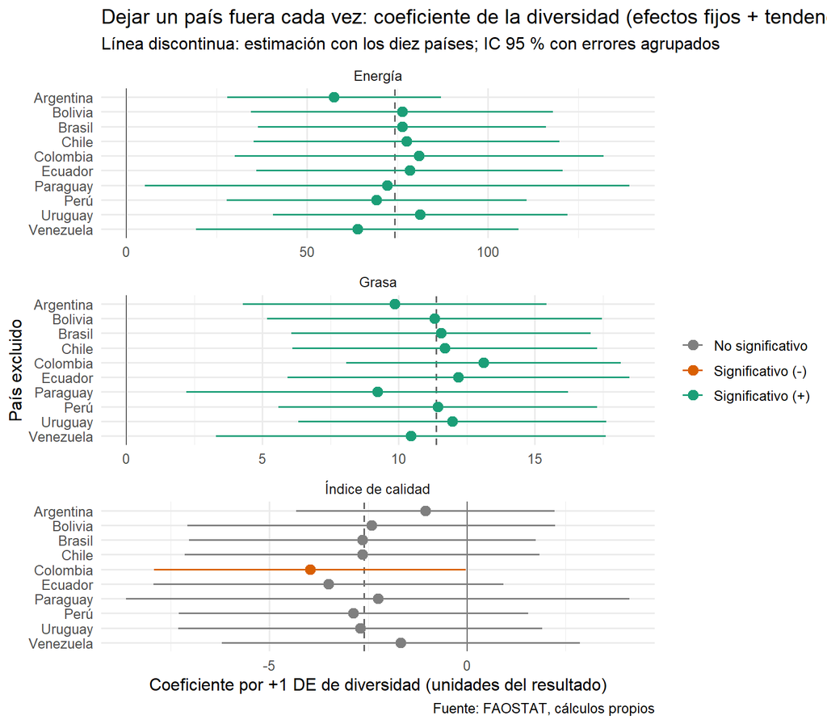

```r
loco |>
  mutate(res = factor(et_res[resultado], levels = et_res), pais_excl = sub("^Sin ", "", verificacion)) |>
  left_join(rob |> filter(str_starts(verificacion, "Base")) |> select(resultado, base = coef), by = "resultado") |>
  ggplot(aes(coef, fct_rev(factor(pais_excl, levels = paises)), color = categoria)) +
  geom_vline(aes(xintercept = base), linetype = "dashed", color = "grey40") +
  geom_vline(xintercept = 0, color = "black", linewidth = 0.3) +
  geom_pointrange(aes(xmin = lo, xmax = hi)) +
  scale_color_manual(values = c("Significativo (+)" = "#1B9E77", "No significativo" = "grey50", "Significativo (-)" = "#D95F02"), name = NULL) +
  facet_wrap(~res, scales = "free_x", ncol = 1) +
  labs(title = "Dejar un país fuera cada vez: coeficiente de la diversidad (efectos fijos + tendencia)",
       subtitle = "Línea discontinua: estimación con los diez países; IC 95 % con errores agrupados",
       x = "Coeficiente por +1 DE de diversidad (unidades del resultado)", y = "País excluido", caption = fuente)
```

```r
base_cat <- rob |> filter(str_starts(verificacion, "Base")) |> select(resultado, base_cat = categoria)
filas_loco <- loco |> left_join(base_cat, by = "resultado") |> group_by(resultado) |>
  summarise(verificacion = "Sin cada país (10 estimaciones; coef. = mediana; p = rango)", coef_med = median(coef),
            p_min = min(p), p_max = max(p),
            n_igual = sum(categoria == base_cat), n_sig = sum(p < 0.05), base_cat = first(base_cat), .groups = "drop") |>
  mutate(igual = n_igual == length(paises), coef = coef_med, p = p_max,
         p_txt = paste0(fpt(p_min), " a ", fpt(p_max)),
         categoria = ifelse(igual, base_cat, paste0("Mixto: ", n_sig, " de ", length(paises), " significativos")))
resumen_rob <- bind_rows(
  rob |> filter(!str_starts(verificacion, "Base")) |> left_join(base_cat, by = "resultado") |>
    mutate(igual = categoria == base_cat, p_txt = fpt(p)) |>
    select(resultado, verificacion, coef, p, p_txt, categoria, base_cat, igual),
  filas_loco |> select(resultado, verificacion, coef, p, p_txt, categoria, base_cat, igual)) |>
  arrange(match(resultado, resultados))

resumen_rob |>
  transmute(Resultado = et_res[resultado], `Verificación` = verificacion, `Coef.` = coef, p = p_txt,
            `Categoría en la verificación` = categoria, `Categoría en la base` = base_cat,
            `¿Se mantiene el resultado?` = ifelse(igual, "Sí", "No")) |>
  kable(digits = 2, caption = "¿Se mantiene el resultado? Comparación con la estimación base (misma categoría = mismo signo y misma significancia al 5 %)")
```

¿Se mantiene el resultado? Comparación con la estimación base (misma categoría = mismo signo y misma significancia al 5 %)

| Resultado | Verificación | Coef. | p | Categoría en la verificación | Categoría en la base | ¿Se mantiene el resultado? |
| --- | --- | --- | --- | --- | --- | --- |
| Energía | Efectos fijos de país y de año | 81.90 | 0.008 | Significativo (+) | Significativo (+) | Sí |
| Energía | Diversidad rezagada un año (t-1) | 75.10 | 0.009 | Significativo (+) | Significativo (+) | Sí |
| Energía | Primeras diferencias | -14.47 | 0.526 | No significativo | Significativo (+) | No |
| Energía | Sin los años de crisis de Venezuela | 89.22 | 0.010 | Significativo (+) | Significativo (+) | Sí |
| Energía | Con controles de comercio (posibles mediadores) | 68.00 | 0.032 | Significativo (+) | Significativo (+) | Sí |
| Energía | Sin cada país (10 estimaciones; coef. = mediana; p = rango) | 76.24 | 0.002 a 0.038 | Significativo (+) | Significativo (+) | Sí |
| Grasa | Efectos fijos de país y de año | 12.30 | 0.002 | Significativo (+) | Significativo (+) | Sí |
| Grasa | Diversidad rezagada un año (t-1) | 9.22 | 0.010 | Significativo (+) | Significativo (+) | Sí |
| Grasa | Primeras diferencias | 4.65 | 0.004 | Significativo (+) | Significativo (+) | Sí |
| Grasa | Sin los años de crisis de Venezuela | 11.79 | 0.002 | Significativo (+) | Significativo (+) | Sí |
| Grasa | Con controles de comercio (posibles mediadores) | 10.81 | 0.002 | Significativo (+) | Significativo (+) | Sí |
| Grasa | Sin cada país (10 estimaciones; coef. = mediana; p = rango) | 11.50 | < 0.001 a 0.016 | Significativo (+) | Significativo (+) | Sí |
| Índice de calidad | Efectos fijos de país y de año | -2.72 | 0.207 | No significativo | No significativo | Sí |
| Índice de calidad | Diversidad rezagada un año (t-1) | -2.42 | 0.220 | No significativo | No significativo | Sí |
| Índice de calidad | Primeras diferencias | 0.78 | 0.665 | No significativo | No significativo | Sí |
| Índice de calidad | Sin los años de crisis de Venezuela | -2.38 | 0.227 | No significativo | No significativo | Sí |
| Índice de calidad | Con controles de comercio (posibles mediadores) | -1.44 | 0.495 | No significativo | No significativo | Sí |
| Índice de calidad | Sin cada país (10 estimaciones; coef. = mediana; p = rango) | -2.65 | 0.049 a 0.482 | Mixto: 1 de 10 significativos | No significativo | No |

**Lectura de la robustez.** **Energía** (base: significativo (+)): el resultado se mantiene en 5 de 6 verificaciones; dejando fuera un país por vez el coeficiente va de 57.45 a 81.21 kcal/día; con diversidad rezagada es +75.10 (p = 0.009), en primeras diferencias -14.47 (p = 0.526) y sin los años de crisis de Venezuela +89.22 (p = 0.010). **Grasa** (base: significativo (+)): el resultado se mantiene en 6 de 6 verificaciones; dejando fuera un país por vez el coeficiente va de 9.21 a 13.12 g/día; con diversidad rezagada es +9.22 (p = 0.010), en primeras diferencias +4.65 (p = 0.004) y sin los años de crisis de Venezuela +11.79 (p = 0.002). **Índice de calidad** (base: no significativo): el resultado se mantiene en 5 de 6 verificaciones; dejando fuera un país por vez el coeficiente va de -3.97 a -1.05 puntos; con diversidad rezagada es -2.42 (p = 0.220), en primeras diferencias +0.78 (p = 0.665) y sin los años de crisis de Venezuela -2.38 (p = 0.227). Algunas verificaciones cambian la categoría de algún resultado: las conclusiones son razonablemente estables pero no uniformes.

# 6 Interpretación en lenguaje claro

1. **Dentro de cada país, la diversidad se asocia con valores más altos de energía.** En los años en que un país tiene una oferta más diversa que su propio promedio, la energía disponible es mayor en 74 kcal/día por cada +1 DE de diversidad (2.5 % de la media; p bootstrap = 0.012). Resiste el bootstrap, y también resiste la corrección de Holm entre los tres resultados.
2. **Grasa.** La diversidad se asocia con valores más altos de grasa disponible (+11.4 g/día por +1 DE; p bootstrap = 0.016, p Holm = 0.038). Energía y grasa se mueven juntas, lo cual es esperable: la grasa aporta una parte importante de las calorías y, además, el índice de diversidad se calcula con la misma oferta que ellas, por lo que la relación puede ser en parte mecánica.
3. **Calidad.** No hay evidencia clara de que la diversidad se asocie con la calidad de la oferta (-2.60 puntos por +1 DE; p bootstrap = 0.256). Leído junto con los resultados anteriores: la diversificación se relaciona con la **cantidad** de energía y grasa, no con la **calidad** según este índice parcial.
4. **Qué tan sólido es.** El modelo agrupado (que mezcla comparaciones entre países) y el de efectos fijos dan coeficientes distintos (incluso con signo distinto en al menos un resultado), por lo que comparar países y comparar un país consigo mismo no responden la misma pregunta. La prueba de Hausman rechaza los efectos aleatorios en 0 de 3 resultados. Con inferencia robusta para pocos grupos, 2 de 3 asociaciones son significativas (2 tras Holm). En la robustez, el patrón base se conserva en todas las verificaciones para 1 de 3 resultados; las verificaciones que lo cambian son: Energía (primeras diferencias); Índice de calidad (al dejar fuera a Colombia). En primeras diferencias (cambios de un año a otro) la asociación con la energía no se sostiene: la relación parece estar más en los niveles que en los movimientos anuales, que son ruidosos. Las conclusiones deben presentarse con la cautela que corresponde a un panel de diez países.

## 6.1 Qué significa para la política alimentaria

Los datos son compatibles con que, en un mismo país, los años de oferta más diversa vayan acompañados de más energía y grasa disponibles. Eso es coherente con una oferta que se amplía y se enriquece en general, pero no respaldan usar la diversidad de la oferta, por sí sola, como indicador o meta de calidad nutricional: diversificar la oferta no garantiza una dieta de mejor calidad según el índice usado. Además, “más energía” o “más grasa” no son necesariamente mejores: según el país, pueden significar corregir un déficit o agravar un exceso. Lo que la evidencia sí permite decir es que conviene seguir **indicadores de calidad separados** (frutas y hortalizas, proporción de energía de grasa) y no inferir calidad a partir de la variedad. Nada de lo anterior establece que una política de diversificación *cause* esos cambios: son asociaciones entre medias nacionales de disponibilidad, no de consumo.

# 7 Pronóstico breve de la energía (ruta secundaria)

El informe v3 dejó la ruta predictiva como análisis secundario y acotado. Aquí se compara, para la energía disponible de cada país, tres modelos contra la referencia ingenua, usando solo la serie de cada país (no la diversidad), con 14 puntos por serie.

- **Ingenuo**: el pronóstico es el último valor observado.
- **Deriva**: último valor más el cambio medio anual histórico (*random walk with drift*).
- **Suavizamiento exponencial de Holt**: nivel y pendiente suavizados (`stats::HoltWinters`, sin estacionalidad; los parámetros se estiman por mínimos cuadrados).
- **ARIMA**: de entre ARIMA(p,1,q) con p y q en {0,1}, con y sin deriva, se elige el de menor AICc en la ventana de entrenamiento (`stats::arima`; se fija una diferenciación porque las series tienen tendencia y son demasiado cortas para pruebas de raíz unitaria fiables). Si algún ajuste falla se usa el ingenuo y se cuenta.

**Validación estrictamente temporal.** No se usa validación cruzada con particiones aleatorias: filtraría información del futuro al pasado (años vecinos del mismo país caerían en entrenamiento y en prueba) y, como las series son persistentes, inflaría el desempeño. Se usan (i) una partición fija (entrenar hasta 2020, evaluar 2021-2023) y (ii) **orígenes móviles** (entrenar con todo hasta el origen y pronosticar hasta tres años adelante, para orígenes desde 2016).

```r
z95 <- qnorm(0.975)
fallos <- new.env(); fallos$n <- 0
pron_uno <- function(y, h, modelo) {
  n <- length(y); hh <- seq_len(h)
  ing <- function(fb = FALSE) { if (fb) fallos$n <- fallos$n + 1; list(m = rep(y[n], h), s = sd(diff(y)) * sqrt(hh)) }
  switch(modelo,
    naive = ing(),
    deriva = { dr <- (y[n] - y[1]) / (n - 1); s <- sd(diff(y) - dr)
               list(m = y[n] + dr * hh, s = s * sqrt(hh * (1 + hh / (n - 1)))) },
    holt = tryCatch({
      f <- HoltWinters(ts(y), gamma = FALSE)
      pr <- predict(f, n.ahead = h, prediction.interval = TRUE, level = 0.95)
      list(m = as.numeric(pr[, "fit"]), s = (as.numeric(pr[, "upr"]) - as.numeric(pr[, "fit"])) / z95)
    }, error = function(e) ing(TRUE)),
    arima = tryCatch({
      tt <- seq_len(n)
      cand <- expand_grid(p = 0:1, q = 0:1, dr = c(FALSE, TRUE))
      # xreg = tt se escribe literal para que predict() pueda reevaluar la llamada
      ajs <- pmap(cand, function(p, q, dr) tryCatch(
        if (dr) arima(y, order = c(p, 1, q), xreg = tt, method = "ML") else arima(y, order = c(p, 1, q), method = "ML"),
        error = function(e) NULL))
      aicc <- map_dbl(ajs, function(a) { if (is.null(a)) return(Inf); k <- length(coef(a)) + 1; ne <- n - 1
        if (ne - k - 1 <= 0) Inf else a$aic + 2 * k * (k + 1) / (ne - k - 1) })
      j <- which.min(aicc); if (!is.finite(aicc[j])) stop("sin ajuste")
      pr <- predict(ajs[[j]], n.ahead = h, newxreg = if (cand$dr[j]) n + hh else NULL)
      list(m = as.numeric(pr$pred), s = as.numeric(pr$se))
    }, error = function(e) ing(TRUE)))
}
modelos <- c(naive = "Ingenuo (último valor)", deriva = "Deriva", holt = "Holt (suavizamiento exponencial)", arima = "ARIMA (mejor AICc)")
series <- split(panel$kcal_dia_total, panel$pais)
origenes <- 2016:(max(anios) - 1)
H <- 3

evalu <- expand_grid(pais = paises, origen = origenes, modelo = names(modelos)) |>
  mutate(res = pmap(list(pais, origen, modelo), function(p, o, m) {
    y <- series[[p]][anios <= o]; h <- min(H, max(anios) - o)
    pr <- pron_uno(y, h, m)
    tibble(h = seq_len(h), ano = o + seq_len(h), pred = pr$m, real = series[[p]][match(o + seq_len(h), anios)])
  })) |> unnest(res) |>
  mutate(err = real - pred, ae = abs(err), ape = 100 * abs(err) / real)
origen_fijo <- 2020
```

```r
metr <- function(d) d |> group_by(modelo) |> summarise(MAE = mean(ae), MAPE = mean(ape), n = n(), .groups = "drop") |>
  arrange(match(modelo, names(modelos)))   # el ingenuo va primero: en un empate gana la referencia más simple
m_fijo <- evalu |> filter(origen == origen_fijo) |> metr()
m_rod  <- evalu |> metr()
m_rod_sv <- evalu |> filter(pais != "Venezuela") |> metr()
tab_pron <- tibble(Modelo = modelos[m_fijo$modelo],
                   `MAE partición fija (kcal)` = m_fijo$MAE, `MAPE partición fija (%)` = m_fijo$MAPE,
                   `MAE orígenes móviles (kcal)` = m_rod$MAE[match(m_fijo$modelo, m_rod$modelo)],
                   `MAPE orígenes móviles (%)` = m_rod$MAPE[match(m_fijo$modelo, m_rod$modelo)],
                   `MAE móviles sin Venezuela (kcal)` = m_rod_sv$MAE[match(m_fijo$modelo, m_rod_sv$modelo)])
kable(tab_pron, digits = 2, caption = paste0("Error de pronóstico de la energía (kcal/día): partición fija (", origen_fijo + 1, "-", max(anios), ", ", unique(m_fijo$n), " pronósticos por modelo) y orígenes móviles (", unique(m_rod$n), " pronósticos por modelo)"))
```

Error de pronóstico de la energía (kcal/día): partición fija (2021-2023, 30 pronósticos por modelo) y orígenes móviles (180 pronósticos por modelo)

| Modelo | MAE partición fija (kcal) | MAPE partición fija (%) | MAE orígenes móviles (kcal) | MAPE orígenes móviles (%) | MAE móviles sin Venezuela (kcal) |
| --- | --- | --- | --- | --- | --- |
| Ingenuo (último valor) | 57.63 | 2.06 | 35.66 | 1.27 | 27.14 |
| Deriva | 75.67 | 2.78 | 51.10 | 1.92 | 31.24 |
| Holt (suavizamiento exponencial) | 78.77 | 2.90 | 60.73 | 2.31 | 36.08 |
| ARIMA (mejor AICc) | 60.02 | 2.15 | 41.98 | 1.48 | 34.17 |

```r
evalu |> filter(origen == origen_fijo) |> group_by(modelo, pais) |> summarise(MAE = mean(ae), .groups = "drop") |>
  mutate(modelo = modelos[modelo]) |> pivot_wider(names_from = pais, values_from = MAE) |>
  kable(digits = 0, caption = paste0("MAE por país en la partición fija (kcal/día): conviene ver dónde se concentra el error"))
```

MAE por país en la partición fija (kcal/día): conviene ver dónde se concentra el error

| modelo | Argentina | Bolivia | Brasil | Chile | Colombia | Ecuador | Paraguay | Perú | Uruguay | Venezuela |
| --- | --- | --- | --- | --- | --- | --- | --- | --- | --- | --- |
| ARIMA (mejor AICc) | 16 | 17 | 56 | 19 | 53 | 33 | 4 | 74 | 32 | 298 |
| Deriva | 16 | 48 | 48 | 19 | 53 | 43 | 24 | 74 | 11 | 421 |
| Holt (suavizamiento exponencial) | 21 | 88 | 48 | 45 | 31 | 89 | 39 | 67 | 14 | 345 |
| Ingenuo (último valor) | 45 | 17 | 52 | 57 | 8 | 33 | 17 | 19 | 32 | 298 |

**Resultado de la validación.** Con orígenes móviles el modelo de menor error absoluto medio es **Ingenuo (último valor)** (MAE = 35.7 kcal/día; MAPE = 1.27 %), es decir, ningún modelo supera a repetir el último valor. La diferencia con la referencia ingenua es pequeña o nula: con tan pocos puntos por país, un modelo más complejo no aporta una ventaja clara. En la partición fija el mejor es Ingenuo (último valor) (el mismo modelo). Sin Venezuela, el mejor sigue siendo el mismo. Con el modelo ganador, el país con mayor error en la partición fija es Venezuela (MAE de 298 kcal/día): su energía pasó de 2 299 kcal/día en 2020 a 2 800 en 2023, un cambio que ningún modelo univariado entrenado con datos hasta 2020 anticipa. Todos los ajustes de Holt y ARIMA convergieron sin recurrir al pronóstico ingenuo de respaldo.

## 7.1 Pronóstico 2024-2026

Se reajusta el modelo ganador de la validación móvil (Ingenuo (último valor)) con toda la serie de cada país y con el promedio regional, y se proyectan tres años con intervalos de predicción al 95 %. Los intervalos son anchos porque la serie es corta y los modelos suponen que el pasado reciente se mantiene (no recogen otro quiebre como el de Venezuela).

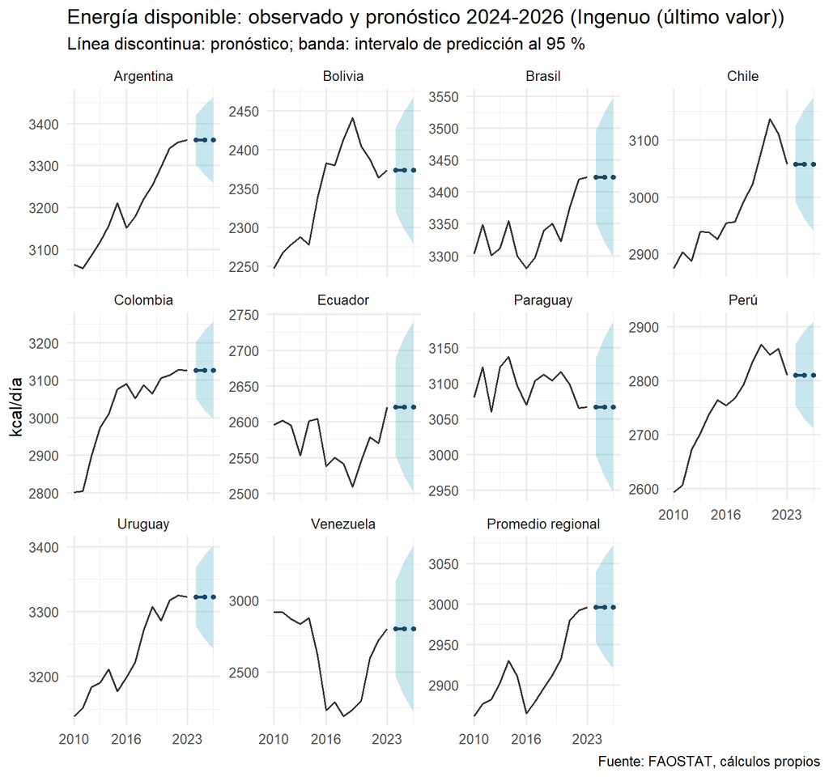

```r
reg <- panel |> group_by(ano) |> summarise(kcal = mean(kcal_dia_total), .groups = "drop")
ser_all <- c(series, list(`Promedio regional` = reg$kcal))
fut <- map_dfr(names(ser_all), function(p) {
  y <- ser_all[[p]]; pr <- pron_uno(y, H, gan_rod)
  tibble(pais = p, ano = max(anios) + seq_len(H), m = pr$m, lo = pr$m - z95 * pr$s, hi = pr$m + z95 * pr$s)
})
hist_df <- bind_rows(panel |> transmute(pais, ano, kcal = kcal_dia_total), reg |> mutate(pais = "Promedio regional"))
orden_f <- c(paises, "Promedio regional")
ggplot() +
  geom_ribbon(data = fut, aes(ano, ymin = lo, ymax = hi), fill = "#62B6CB", alpha = 0.35) +
  geom_line(data = hist_df, aes(ano, kcal), color = "grey20") +
  geom_line(data = fut, aes(ano, m), color = "#1B4965", linewidth = 1, linetype = "dashed") +
  geom_point(data = fut, aes(ano, m), color = "#1B4965", size = 1.2) +
  facet_wrap(~factor(pais, levels = orden_f), scales = "free_y", ncol = 4) +
  scale_x_continuous(breaks = c(2010, 2016, 2023)) +
  labs(title = paste0("Energía disponible: observado y pronóstico ", max(anios) + 1, "-", max(anios) + H, " (", modelos[gan_rod], ")"),
       subtitle = "Línea discontinua: pronóstico; banda: intervalo de predicción al 95 %",
       x = NULL, y = "kcal/día", caption = fuente)
```

```r
fut |> filter(pais == "Promedio regional") |>
  transmute(`Año` = ano, `Pronóstico (kcal/día)` = m, `Límite inferior 95 %` = lo, `Límite superior 95 %` = hi) |>
  kable(digits = 0, caption = "Promedio regional de energía (media simple de los diez países): pronóstico con intervalo al 95 %")
```

Promedio regional de energía (media simple de los diez países): pronóstico con intervalo al 95 %

| Año | Pronóstico (kcal/día) | Límite inferior 95 % | Límite superior 95 % |
| --- | --- | --- | --- |
| 2024 | 2996 | 2952 | 3040 |
| 2025 | 2996 | 2934 | 3058 |
| 2026 | 2996 | 2920 | 3072 |

El pronóstico del promedio regional para 2026 es de 2 996 kcal/día (intervalo 2 920 a 3 072), igual al último dato observado (2 996 en 2023); el intervalo mide 152 kcal/día de ancho, es decir, 5.1 % del nivel. Es un ejercicio de apoyo: el objetivo principal del informe es el diagnóstico.

# 8 Limitaciones

- **Solo 10 países.** La inferencia con pocos grupos es frágil por naturaleza: aun el bootstrap salvaje tiene poca potencia, y un resultado “no significativo” no demuestra que no haya relación.
- **Disponibilidad no es consumo.** Las Hojas de Balance de Alimentos miden la oferta nacional disponible (producción + importaciones - exportaciones - otros usos), no lo que come cada persona; no reflejan acceso, desigualdad ni desperdicio.
- **Posibles revisiones metodológicas.** La FAO revisa sus series; los saltos de algunos países (Venezuela, exportaciones de Brasil en el último año) pueden reflejar cambios de registro y no de la oferta real.
- **Variables omitidas.** No hay ingreso, precios, población ni clima. Pueden mover a la vez la diversidad y los nutrientes; los efectos fijos solo controlan lo que no cambia en el tiempo, y la tendencia o los efectos de año solo lo que es común a todos los países.
- **Relación parcialmente mecánica.** El índice de diversidad y la energía, la grasa y el índice de calidad provienen de la misma oferta (el índice de calidad usa la proporción de energía de grasa): parte de la asociación puede ser aritmética y no económica o conductual.
- **Series cortas.** 14 años por país: Driscoll-Kraay y las pruebas de autocorrelación son aproximadas, y el pronóstico se apoya en muy pocos puntos.
- **Causalidad inversa y simultaneidad.** Más energía disponible podría ampliar la variedad (y no al revés); el rezago de un año mitiga el orden temporal pero no resuelve la causalidad.
- **Proteína fuera del panel.** No se evalúa dentro de cada país.
- **Índice de calidad parcial.** Solo incluye frutas y hortalizas y energía de grasa, con efecto techo.

# 9 Conclusión

Dentro de cada país, entre 2010 y 2023, la diversidad de la oferta se asocia con valores más altos de energía (+74 kcal/día por +1 DE; p bootstrap = 0.012), se asocia con valores más altos de grasa (+11.4 g/día; p = 0.016) y no muestra una asociación clara con calidad (-2.60 puntos; p = 0.256). El resultado se mantiene en todas las verificaciones de robustez para 1 de 3 resultados, y se interpreta siempre como **asociación**, no como efecto causal. La lectura más prudente es que diversificar la oferta se relaciona con más cantidad, no con mejor calidad medida con este índice. En el pronóstico secundario, repetir el último valor no es superado por los modelos más elaborados; con series tan cortas es esperable que no haya ventaja material sobre la referencia ingenua. Como siguiente paso, ampliar la muestra (más países y años) e incorporar ingreso y precios aumentaría la potencia y permitiría separar mejor la diversidad de los factores que la acompañan.

# 10 Referencias

- FAO. *FAOSTAT: base de datos estadísticos de la FAO*. https://www.fao.org/faostat
- Wooldridge, J. M. (2010). *Econometric Analysis of Cross Section and Panel Data* (2.ª ed.). MIT Press.
- Cameron, A. C., Gelbach, J. B. y Miller, D. L. (2008). Bootstrap-based improvements for inference with clustered errors. *Review of Economics and Statistics*, 90(3), 414-427.
- Webb, M. D. (2014). Reworking wild bootstrap based inference for clustered errors. *Queen’s Economics Department Working Paper* 1315.
- Driscoll, J. C. y Kraay, A. C. (1998). Consistent covariance matrix estimation with spatially dependent panel data. *Review of Economics and Statistics*, 80(4), 549-560.
- Croissant, Y. y Millo, G. (2008). Panel data econometrics in R: the plm package. *Journal of Statistical Software*, 27(2).
- Hyndman, R. J. y Athanasopoulos, G. (2021). *Forecasting: Principles and Practice* (3.ª ed.). OTexts.

# 11 Anexo: información de sesión